# Data Science Challenge

```python
# If you'd like to install packages that aren't installed by default, uncomment the last two lines of this cell and replace <package list> with a list of your packages.
# This will ensure your notebook has all the dependencies and works everywhere

#import sys
#!{sys.executable} -m pip install <package list>
```

```python
#Libraries
import pandas as pd
pd.set_option("display.max_columns", 101)
import numpy as np
import seaborn as sns
import matplotlib.pyplot as plt
%matplotlib inline
import warnings
warnings.filterwarnings('ignore')
from statsmodels.stats.outliers_influence import variance_inflation_factor
```

## Data Description

[output not shown]

## Data Wrangling & Visualization

```python
# Dataset is already loaded below
data = pd.read_csv("Train.csv")
```

```python
data.head()
```

|  | id | Loan Amount | Term | State | Annual Income | Income Verification Status | Average Account Balance | Due Amount | Home Ownership | Loan Purpose | Due Settlement | Installment Amount | Payment Plan | Approve Loan |
| --- | --- | --- | --- | --- | --- | --- | --- | --- | --- | --- | --- | --- | --- | --- |
| 0 | 1267 | 25000.0 | 36 months | CO | 50000.0 | Partially Verified | 4073.0 | 783.30 | OWN | credit_card | N | 783.30 | n | 1 |
| 1 | 1 | 8000.0 | 36 months | FL | 65000.0 | Partially Verified | 2298.0 | 263.78 | RENT | debt_consolidation | Y | 263.78 | n | 1 |
| 2 | 2219 | 11000.0 | 36 months | MI | 49000.0 | Verified | 1441.0 | 3978.72 | MORTGAGE | debt_consolidation | N | 342.12 | n | 1 |
| 3 | 453 | 35000.0 | 36 months | CA | 108000.0 | Verified | 33603.0 | 1154.00 | MORTGAGE | credit_card | Y | 1154.00 | n | 1 |
| 4 | 1108 | 35000.0 | 36 months | CA | 87000.0 | Partially Verified | 3399.0 | 1300.55 | RENT | debt_consolidation | Y | 1300.55 | n | 0 |

```python
#Explore columns
data.columns
```

```
Index(['id', 'Loan Amount', 'Term', 'State', 'Annual Income',
       'Income Verification Status', 'Average Account Balance', 'Due Amount',
       'Home Ownership', 'Loan Purpose', 'Due Settlement',
       'Installment Amount', 'Payment Plan', 'Approve Loan'],
      dtype='object')
```

```python
#Description
data.describe()
```

|  | id | Loan Amount | Annual Income | Average Account Balance | Due Amount | Installment Amount | Approve Loan |
| --- | --- | --- | --- | --- | --- | --- | --- |
| count | 1894.000000 | 1800.000000 | 1822.000000 | 1788.000000 | 1853.000000 | 1878.000000 | 1894.000000 |
| mean | 1273.117212 | 14999.013889 | 77178.816120 | 12672.040268 | 2245.644058 | 479.828408 | 0.563886 |
| std | 740.130069 | 9275.904382 | 50209.852895 | 15373.593687 | 5058.409367 | 299.898845 | 0.496033 |
| min | 0.000000 | 1000.000000 | 1000.000000 | 17.000000 | 0.000000 | 30.120000 | 0.000000 |
| 25% | 629.250000 | 8000.000000 | 47218.750000 | 2936.750000 | 220.140000 | 259.990000 | 0.000000 |
| 50% | 1289.500000 | 12775.000000 | 65900.000000 | 6463.000000 | 462.900000 | 397.785000 | 1.000000 |
| 75% | 1910.750000 | 20000.000000 | 90000.000000 | 17959.000000 | 992.730000 | 631.070000 | 1.000000 |
| max | 2565.000000 | 40000.000000 | 575000.000000 | 196292.000000 | 40471.140000 | 1503.890000 | 1.000000 |

```python
data.columns = data.columns.str.replace(' ', '')
data.columns
```

```
Index(['id', 'LoanAmount', 'Term', 'State', 'AnnualIncome',
       'IncomeVerificationStatus', 'AverageAccountBalance', 'DueAmount',
       'HomeOwnership', 'LoanPurpose', 'DueSettlement', 'InstallmentAmount',
       'PaymentPlan', 'ApproveLoan'],
      dtype='object')
```

### From the data description, there are tendencies for outliers to be present in the data (numerical columns)

### Segmenting the data into target and independent features set (y and X)

```python
# Segmenting the data into target (y) and features list (X)
print(data.shape)
print(data['ApproveLoan'].value_counts())
target_means = data.groupby('State')['ApproveLoan'].mean()
data['State'] = data['State'].map(target_means)
data.head()
X = data.iloc[:,:-1]
y = data.iloc[:, -1]
print(X.shape, y.shape)
```

```
(1894, 14)
1    1068
0     826
Name: ApproveLoan, dtype: int64
(1894, 13) (1894,)
```

### After analysis, as number of states is really high, therefore it was decided that states will be target encoded whereas for the other categorical columns dummification will be applied.

```python
X.head()
```

|  | id | LoanAmount | Term | State | AnnualIncome | IncomeVerificationStatus | AverageAccountBalance | DueAmount | HomeOwnership | LoanPurpose | DueSettlement | InstallmentAmount | PaymentPlan |
| --- | --- | --- | --- | --- | --- | --- | --- | --- | --- | --- | --- | --- | --- |
| 0 | 1267 | 25000.0 | 36 months | 0.527778 | 50000.0 | Partially Verified | 4073.0 | 783.30 | OWN | credit_card | N | 783.30 | n |
| 1 | 1 | 8000.0 | 36 months | 0.615385 | 65000.0 | Partially Verified | 2298.0 | 263.78 | RENT | debt_consolidation | Y | 263.78 | n |
| 2 | 2219 | 11000.0 | 36 months | 0.618182 | 49000.0 | Verified | 1441.0 | 3978.72 | MORTGAGE | debt_consolidation | N | 342.12 | n |
| 3 | 453 | 35000.0 | 36 months | 0.503448 | 108000.0 | Verified | 33603.0 | 1154.00 | MORTGAGE | credit_card | Y | 1154.00 | n |
| 4 | 1108 | 35000.0 | 36 months | 0.503448 | 87000.0 | Partially Verified | 3399.0 | 1300.55 | RENT | debt_consolidation | Y | 1300.55 | n |

```python
# Checking data types to understand categorical variables and numerical variables
X.dtypes
```

```
id                            int64
LoanAmount                  float64
Term                         object
State                       float64
AnnualIncome                float64
IncomeVerificationStatus     object
AverageAccountBalance       float64
DueAmount                   float64
HomeOwnership                object
LoanPurpose                  object
DueSettlement                object
InstallmentAmount           float64
PaymentPlan                  object
dtype: object
```

```python
# We do not require the loan id as an input feature
# we can join this to the final output in order to get which loans to approve
df_loan_id = X['id']
X.drop('id', axis = 1, inplace = True)
X.head()
```

|  | LoanAmount | Term | State | AnnualIncome | IncomeVerificationStatus | AverageAccountBalance | DueAmount | HomeOwnership | LoanPurpose | DueSettlement | InstallmentAmount | PaymentPlan |
| --- | --- | --- | --- | --- | --- | --- | --- | --- | --- | --- | --- | --- |
| 0 | 25000.0 | 36 months | 0.527778 | 50000.0 | Partially Verified | 4073.0 | 783.30 | OWN | credit_card | N | 783.30 | n |
| 1 | 8000.0 | 36 months | 0.615385 | 65000.0 | Partially Verified | 2298.0 | 263.78 | RENT | debt_consolidation | Y | 263.78 | n |
| 2 | 11000.0 | 36 months | 0.618182 | 49000.0 | Verified | 1441.0 | 3978.72 | MORTGAGE | debt_consolidation | N | 342.12 | n |
| 3 | 35000.0 | 36 months | 0.503448 | 108000.0 | Verified | 33603.0 | 1154.00 | MORTGAGE | credit_card | Y | 1154.00 | n |
| 4 | 35000.0 | 36 months | 0.503448 | 87000.0 | Partially Verified | 3399.0 | 1300.55 | RENT | debt_consolidation | Y | 1300.55 | n |

```python
numerical_cols = X._get_numeric_data().columns
print(numerical_cols)
categorical_cols = [x for x in X.columns if x not in numerical_cols]
print(categorical_cols)
```

```
Index(['LoanAmount', 'State', 'AnnualIncome', 'AverageAccountBalance',
       'DueAmount', 'InstallmentAmount'],
      dtype='object')
['Term', 'IncomeVerificationStatus', 'HomeOwnership', 'LoanPurpose', 'DueSettlement', 'PaymentPlan']
```

### Understanding data distributions segregating via the target column which is the Approve Loan

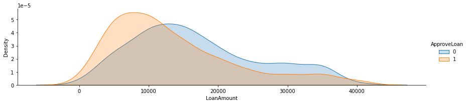

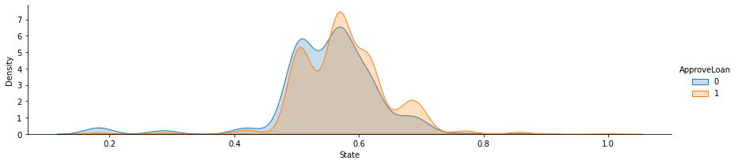

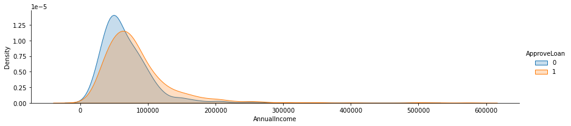

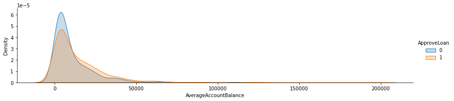

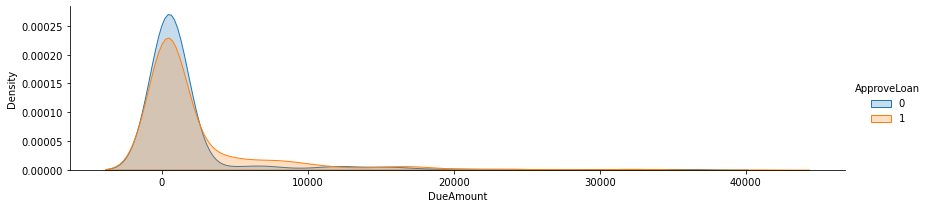

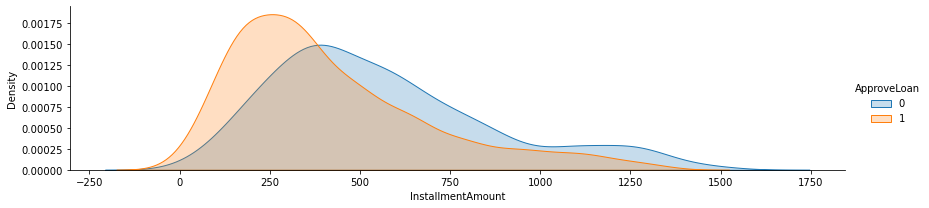

```python
for i in numerical_cols:
    facet = sns.FacetGrid(data, hue="ApproveLoan", aspect=4)
    facet.map(sns.kdeplot, i, shade = True)
    facet.add_legend()
    plt.show()
```

#### From the distribution of the numerical columns, installment amount and loan amount have similar information and might be helpful in model training. Also, observing the distributions at a first glance, we also need to check for multicollinearity

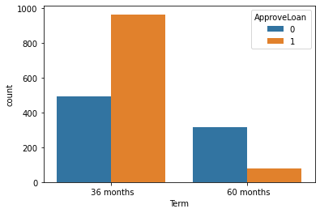

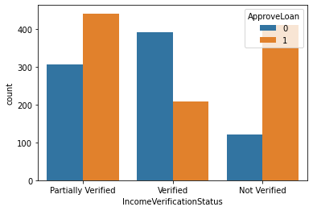

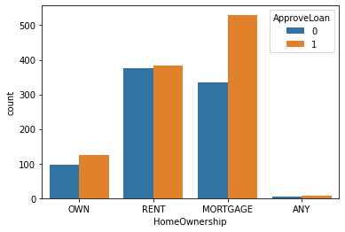

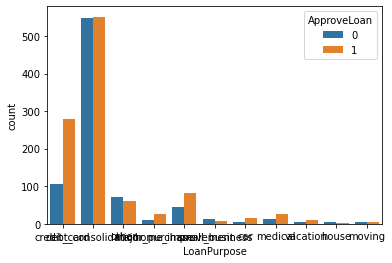

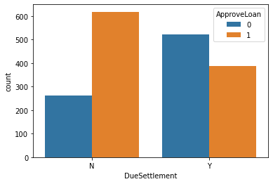

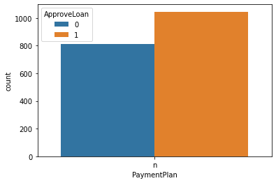

```python
for i in categorical_cols:
    sns.countplot(x=i,
                   data=data,
                   hue='ApproveLoan')
    plt.show()
```

#### From the observations, on the categorical columns segregated by target column, due settlement, income verification status, term and customers with home ownership as mortgage might have segmentation information for the ML model to distinguish between approve loan 0 and 1

### Basic preprocessing class

```python
# Checking for null values
X.isnull().sum()
```

```
LoanAmount                   94
Term                         44
State                         0
AnnualIncome                 72
IncomeVerificationStatus     15
AverageAccountBalance       106
DueAmount                    41
HomeOwnership                36
LoanPurpose                   0
DueSettlement               107
InstallmentAmount            16
PaymentPlan                  37
dtype: int64
```

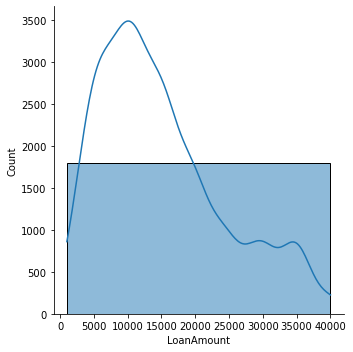

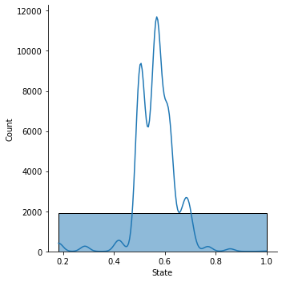

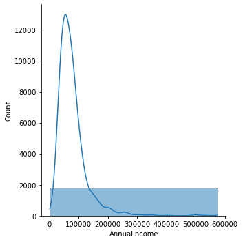

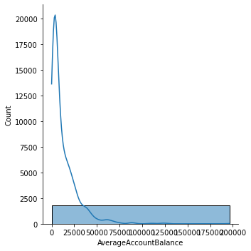

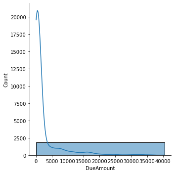

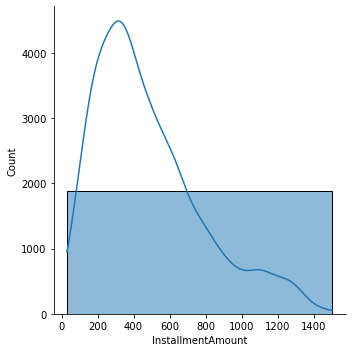

```python
# Plotting graph to see the distribution to check for numerical columns whether to impute with mean or median
for i in numerical_cols:
    sns.displot(X[i], kde=True, bins=1)
```

```python
class basic_preprocessing:

    def __init__(self, X, y, numerical_cols, categorical_cols):
        self.X = X
        self.y = y
        self.numerical_cols = numerical_cols
        self.categorical_cols = categorical_cols
        self.dictionary = {}

    def imputation(self):
        # here only the numerical columns will be captured and null values will be replaced with median
        self.X = self.X.fillna(self.X.median())

        #running a loop to convert null from categorical columns with mode
        for i in self.categorical_cols:
            self.X[i] = self.X[i].fillna(self.X[i].mode().iloc[0])

    def outlier_treatment(self):
        for i in self.numerical_cols:
            percentile_25 = self.X[i].quantile(0.25)
            percentile_75 = self.X[i].quantile(0.75)
            iqr = percentile_75 - percentile_25
            upper_limit = percentile_75 + 1.5 * iqr
            lower_limit = percentile_25 - 1.5 * iqr
            # print('column: ', i, 'upper limit: ', upper_limit, 'lower_limit: ', lower_limit)

            self.X = self.X[(self.X[i] < upper_limit) & (self.X[i] > lower_limit)]


            # to see if we can afford removing all rows with any outlier value
            self.dictionary[i] = [upper_limit, lower_limit]
        print(self.dictionary)


    def calculate_outlier_percentage(self, row, threshold=2):
        z_scores = np.abs((row - row.mean()) / row.std())
        outliers_percentage = (z_scores > threshold).sum() / len(row) * 100
        return outliers_percentage



    def dummification(self):
        # not putting state column here as already target encoding is done for state column
        self.X = pd.get_dummies(self.X, columns = [x for x in self.categorical_cols if x not in 'State'], drop_first = True)


    def preprocessing(self):
        self.imputation()
        print('before outlier treatment: ', self.X.shape)
        # self.outlier_treatment()
        # self.X['Outlier_Percentage'] = self.X.apply(self.calculate_outlier_percentage, axis = 1)
        print('after outlier treatment: ', self.X.shape)
        print(self.X.columns)
        print(self.categorical_cols)
        self.dummification()

        return self.X, self.y, self.dictionary
```

```python
obj = basic_preprocessing(X, y, numerical_cols, categorical_cols)
X_treated, y_treated, dictionary = obj.preprocessing()
```

```
before outlier treatment:  (1894, 12)
after outlier treatment:  (1894, 12)
Index(['LoanAmount', 'Term', 'State', 'AnnualIncome',
       'IncomeVerificationStatus', 'AverageAccountBalance', 'DueAmount',
       'HomeOwnership', 'LoanPurpose', 'DueSettlement', 'InstallmentAmount',
       'PaymentPlan'],
      dtype='object')
['Term', 'IncomeVerificationStatus', 'HomeOwnership', 'LoanPurpose', 'DueSettlement', 'PaymentPlan']
```

```python
print(X_treated.shape, y_treated.shape)
X_treated.head()
```

```
(1894, 23) (1894,)
```

|  | LoanAmount | State | AnnualIncome | AverageAccountBalance | DueAmount | InstallmentAmount | Term_ 60 months | IncomeVerificationStatus_Partially Verified | IncomeVerificationStatus_Verified | HomeOwnership_MORTGAGE | HomeOwnership_OWN | HomeOwnership_RENT | LoanPurpose_credit_card | LoanPurpose_debt_consolidation | LoanPurpose_home_improvement | LoanPurpose_house | LoanPurpose_major_purchase | LoanPurpose_medical | LoanPurpose_moving | LoanPurpose_other | LoanPurpose_small_business | LoanPurpose_vacation | DueSettlement_Y |
| --- | --- | --- | --- | --- | --- | --- | --- | --- | --- | --- | --- | --- | --- | --- | --- | --- | --- | --- | --- | --- | --- | --- | --- |
| 0 | 25000.0 | 0.527778 | 50000.0 | 4073.0 | 783.30 | 783.30 | 0 | 1 | 0 | 0 | 1 | 0 | 1 | 0 | 0 | 0 | 0 | 0 | 0 | 0 | 0 | 0 | 0 |
| 1 | 8000.0 | 0.615385 | 65000.0 | 2298.0 | 263.78 | 263.78 | 0 | 1 | 0 | 0 | 0 | 1 | 0 | 1 | 0 | 0 | 0 | 0 | 0 | 0 | 0 | 0 | 1 |
| 2 | 11000.0 | 0.618182 | 49000.0 | 1441.0 | 3978.72 | 342.12 | 0 | 0 | 1 | 1 | 0 | 0 | 0 | 1 | 0 | 0 | 0 | 0 | 0 | 0 | 0 | 0 | 0 |
| 3 | 35000.0 | 0.503448 | 108000.0 | 33603.0 | 1154.00 | 1154.00 | 0 | 0 | 1 | 1 | 0 | 0 | 1 | 0 | 0 | 0 | 0 | 0 | 0 | 0 | 0 | 0 | 1 |
| 4 | 35000.0 | 0.503448 | 87000.0 | 3399.0 | 1300.55 | 1300.55 | 0 | 1 | 0 | 0 | 0 | 1 | 0 | 1 | 0 | 0 | 0 | 0 | 0 | 0 | 0 | 0 | 1 |

## Visualization, Modeling, Machine Leaning

Can you identify which loan applications will be approved and identify how different features influence loan approval? Please explain your findings to a technical and non-technical audience using comments and visualizations, if appropriate.

- **Build an optimized model that effectively solves the business problem.**
- **The model would be evaluated on the basis of accuracy.**
- **Read the Test.csv file and prepare features for testing.**

### Feature Selection

#### Focusing on the numerical columns first

```python
X_treated[numerical_cols].corr().style.background_gradient(cmap = 'coolwarm')
```

|  | LoanAmount | State | AnnualIncome | AverageAccountBalance | DueAmount | InstallmentAmount |
| --- | --- | --- | --- | --- | --- | --- |
| LoanAmount | 1.000000 | -0.005161 | 0.415309 | 0.162030 | 0.255513 | 0.934124 |
| State | -0.005161 | 1.000000 | 0.038977 | 0.020923 | 0.038643 | -0.015168 |
| AnnualIncome | 0.415309 | 0.038977 | 1.000000 | 0.331823 | 0.160027 | 0.382062 |
| AverageAccountBalance | 0.162030 | 0.020923 | 0.331823 | 1.000000 | 0.117047 | 0.153151 |
| DueAmount | 0.255513 | 0.038643 | 0.160027 | 0.117047 | 1.000000 | 0.252390 |
| InstallmentAmount | 0.934124 | -0.015168 | 0.382062 | 0.153151 | 0.252390 | 1.000000 |

```python
corr_matrix = X_treated[numerical_cols].corr().abs()
upper_triangle = corr_matrix.where(np.triu(np.ones(corr_matrix.shape), k=1).astype(np.bool))
numerical_cols_to_remove = [column for column in upper_triangle.columns if any(upper_triangle[column] > 0.7)]
print(numerical_cols_to_remove)
```

```
['InstallmentAmount']
```

```python
def calc_vif(X):

    # Calculating VIF
    vif = pd.DataFrame()
    vif["variables"] = X.columns
    vif["VIF"] = [variance_inflation_factor(X.values, i) for i in range(X.shape[1])]

    return(vif)

VIF_value = calc_vif(X_treated[numerical_cols])
print(VIF_value)
features_to_take = VIF_value[VIF_value['VIF']<= 5].variables.to_list()
print(features_to_take)
```

```
               variables        VIF
0             LoanAmount  30.077436
1                  State   4.471511
2           AnnualIncome   4.522901
3  AverageAccountBalance   1.889700
4              DueAmount   1.289016
5      InstallmentAmount  28.043907
['State', 'AnnualIncome', 'AverageAccountBalance', 'DueAmount']
```

#### Feature Selection for Categorical Columns

```python
from sklearn.feature_selection import chi2
reqd_features = [x for x in X_treated.columns if x not in numerical_cols]
print(reqd_features)
# X_treated[reqd_features]
chi_scores = chi2(X_treated[reqd_features], y)
chi_scores
```

```
['Term_ 60 months', 'IncomeVerificationStatus_Partially Verified', 'IncomeVerificationStatus_Verified', 'HomeOwnership_MORTGAGE', 'HomeOwnership_OWN', 'HomeOwnership_RENT', 'LoanPurpose_credit_card', 'LoanPurpose_debt_consolidation', 'LoanPurpose_home_improvement', 'LoanPurpose_house', 'LoanPurpose_…
```

```
(array([2.12254835e+02, 2.07988286e+00, 1.15121562e+02, 9.28181400e+00,
        7.04549725e-03, 1.08439637e+01, 4.17929630e+01, 1.74686468e+01,
        3.72101746e+00, 5.21189356e-01, 2.89930630e+00, 9.43689196e-01,
        2.53970269e-03, 5.97078481e+00, 2.14360839e+00, 4.78212500e-01,
        5.94737324e+01]),
 array([4.42524194e-48, 1.49251630e-01, 7.40181442e-27, 2.31440116e-03,
        9.33106156e-01, 9.91183353e-04, 1.01467954e-10, 2.92085177e-05,
        5.37316197e-02, 4.70334777e-01, 8.86176815e-02, 3.31330877e-01,
        9.59807252e-01, 1.45448061e-02, 1.43164800e-01, 4.89233098e-01,
        1.23937413e-14]))
```

##### Here, the first array represents chi square values and the second array represents p values

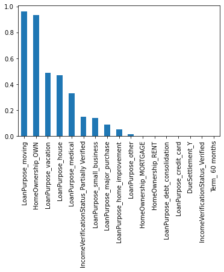

```python
p_values = pd.Series(chi_scores[1],index = X_treated[reqd_features].columns)
p_values.sort_values(ascending = False , inplace = True)
p_values.plot.bar()
```

```python
removal_df_cat = pd.DataFrame(p_values).reset_index()
removal_df_cat.columns = ['col_name', 'p_value']
categorical_cols_to_remove = removal_df_cat[removal_df_cat['p_value']>0.05]['col_name'].to_list()
categorical_cols_to_remove
```

```
['LoanPurpose_moving',
 'HomeOwnership_OWN',
 'LoanPurpose_vacation',
 'LoanPurpose_house',
 'LoanPurpose_medical',
 'IncomeVerificationStatus_Partially Verified',
 'LoanPurpose_small_business',
 'LoanPurpose_major_purchase',
 'LoanPurpose_home_improvement']
```

### All columns which needs to be dropped

```python
print(categorical_cols_to_remove)
```

```
['LoanPurpose_moving', 'HomeOwnership_OWN', 'LoanPurpose_vacation', 'LoanPurpose_house', 'LoanPurpose_medical', 'IncomeVerificationStatus_Partially Verified', 'LoanPurpose_small_business', 'LoanPurpose_major_purchase', 'LoanPurpose_home_improvement']
```

```python
drop_cols = numerical_cols_to_remove
for i in categorical_cols_to_remove:

    drop_cols.append(i)
drop_cols
```

```
['InstallmentAmount',
 'LoanPurpose_moving',
 'HomeOwnership_OWN',
 'LoanPurpose_vacation',
 'LoanPurpose_house',
 'LoanPurpose_medical',
 'IncomeVerificationStatus_Partially Verified',
 'LoanPurpose_small_business',
 'LoanPurpose_major_purchase',
 'LoanPurpose_home_improvement']
```

#### Final dataset to be used for modeling

```python
X_final = X_treated.drop(drop_cols, axis = 1)
X_final.columns
```

```
Index(['LoanAmount', 'State', 'AnnualIncome', 'AverageAccountBalance',
       'DueAmount', 'Term_ 60 months', 'IncomeVerificationStatus_Verified',
       'HomeOwnership_MORTGAGE', 'HomeOwnership_RENT',
       'LoanPurpose_credit_card', 'LoanPurpose_debt_consolidation',
       'LoanPurpose_other', 'DueSettlement_Y'],
      dtype='object')
```

### Model Training

```python
# Importing Classifier Modules
from sklearn.tree import DecisionTreeClassifier
from sklearn.ensemble import RandomForestClassifier,GradientBoostingClassifier
from xgboost import XGBClassifier
from sklearn.naive_bayes import GaussianNB
from sklearn.svm import SVC
from sklearn.model_selection import KFold
from sklearn.model_selection import cross_val_score
k_fold = KFold(n_splits=10, shuffle=True, random_state=0)
```

```python
X_train = X_final
y_train = y_treated
```

##### Understanding base performance from various models without hyperparameter tuning

```python
#learning_rates = [0.05, 0.1, 0.25, 0.5, 0.75, 1]
clf = [DecisionTreeClassifier(),
       RandomForestClassifier(n_estimators=13),
      GradientBoostingClassifier(n_estimators=10, learning_rate=1,max_features=3, max_depth =3, random_state = 10), XGBClassifier()]
def model_fit():
    scoring = 'accuracy'
#     scoring = 'recall'
    for i in range(len(clf)):
        score = cross_val_score(clf[i], X_train, y_train, cv=k_fold, n_jobs=1, scoring=scoring)
        print("Score of Model",clf[i],":",round(np.mean(score)*100,2))
model_fit()
```

[output not shown]

#### Therefore, fine tuning the XGB model using grid search CV and going ahead with it

```python
from sklearn.model_selection import GridSearchCV
xgb=XGBClassifier(random_state=42)
param_grid = {
    'n_estimators': [100, 200, 500],
    'max_depth' : [4,5,6,7],
    'learning_rate' : [0.01, 0.1, 1]
}

CV_xgb = GridSearchCV(estimator=xgb, param_grid=param_grid, cv= 5)
CV_xgb.fit(X_train, y_train)
CV_xgb.best_params_
```

[output not shown]

[output cut: 164 more lines]

```
{'learning_rate': 0.1, 'max_depth': 5, 'n_estimators': 500}
```

```python
final_model = CV_xgb.best_estimator_
final_model.fit(X_train, y_train)
y_pred_train = final_model.predict(X_train)
```

[output not shown]

```python
from sklearn.metrics import accuracy_score, classification_report, confusion_matrix
print(confusion_matrix(y_train, y_pred_train))
print(classification_report(y_train, y_pred_train))
```

```
[[ 825    1]
 [   1 1067]]
              precision    recall  f1-score   support

           0       1.00      1.00      1.00       826
           1       1.00      1.00      1.00      1068

    accuracy                           1.00      1894
   macro avg       1.00      1.00      1.00      1894
weighted avg       1.00      1.00      1.00      1894
```